# Exploratory Data Analysis

- Show All Code
- Hide All Code

Author

Ozge Yasar

Published

February 20, 2025

```python
from predicting_customer_subscription.eda_utils import *
import plotly.io as pio
pio.renderers.default = "png"
```

## 1 1. Dataset

Based on the results below, here’s the summary of the dataset: * The dataset is consist of 15 columns. 4 of these include numerical values, 10 of them are categorical variables, and the colum ‘y’ is the binary outcome variable. * The columns don’t have any missing values * The positive output ratio is around 1 to 9 (11% to 89%) which indicates an imbalance (but not too bad for now).

```python
df = pd.read_excel('../data/train_file.xlsx')
```

```python
data_summary(df, outcome_col= 'y', head_rows=5)
```

```
Head:
   age           job   marital          education  default housing loan  \
0   49   blue-collar   married           basic.9y  unknown      no   no
1   37  entrepreneur   married  university.degree       no      no   no
2   78       retired   married           basic.4y       no      no   no
3   36        admin.   married  university.degree       no     yes   no
4   59       retired  divorced  university.degree       no      no   no

     contact month day_of_week  duration  campaign  previous     poutcome    y
0   cellular   nov         wed       227         4         0  nonexistent   no
1  telephone   nov         wed       202         2         1      failure   no
2   cellular   jul         mon      1148         1         0  nonexistent  yes
3  telephone   may         mon       120         2         0  nonexistent   no
4   cellular   jun         tue       368         2         0  nonexistent   no

Data Types:
age             int64
job            object
marital        object
education      object
default        object
housing        object
loan           object
contact        object
month          object
day_of_week    object
duration        int64
campaign        int64
previous        int64
poutcome       object
y              object
dtype: object

Missing Values:
age            0
job            0
marital        0
education      0
default        0
housing        0
```

[output cut: 12 more lines]

```
y
no     0.89
yes    0.11
Name: proportion, dtype: float64

Column stats:
                age      duration      campaign      previous
count  32910.000000  32910.000000  32910.000000  32910.000000
mean      40.014099    258.164327      2.560620      0.174810
std       10.402948    259.070260      2.753336      0.499211
min       17.000000      0.000000      1.000000      0.000000
25%       32.000000    103.000000      1.000000      0.000000
50%       38.000000    180.000000      2.000000      0.000000
75%       47.000000    319.000000      3.000000      0.000000
max       98.000000   4918.000000     56.000000      7.000000
```

## 2 2. Correlations

Correlations among the continous variables are quite weak as can be seen from the matrix below.

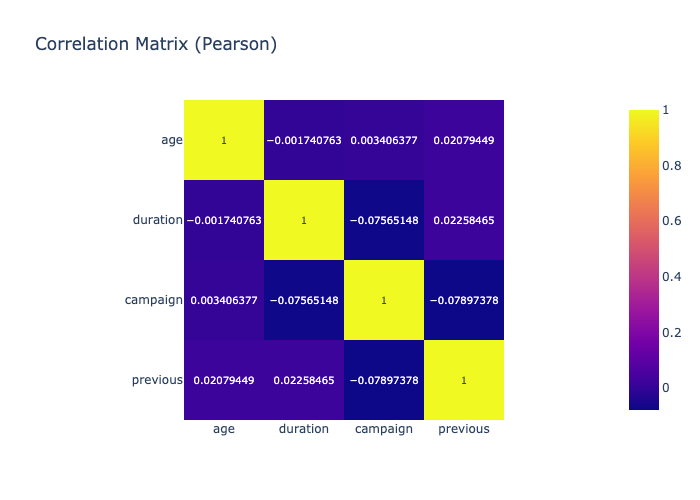

```python
plot_correlation_matrix(df, num_columns=['age', 'duration', 'campaign', 'previous'], method= 'pearson')
```

```python
l_num_cols=['age', 'duration', 'campaign', 'previous']
l_cat_cols=['job', 'marital', 'education', 'default', 'housing', 'loan', 'contact', 'month', 'day_of_week', 'poutcome']
```

## 3 3. Distributions - Continous Variables

- Skewed distributions for all variables with outliers especially for duration variable (average is 258)
- Relationships of the continous variables with the outcome shows some interesting insights.
- Based on the histograms below, the marketing of the product seems to be more successful among the middle age group (30-40), however, it doesn’t indicate a direct relationship given the number of customers contacted within this age group
- Duration (call duration) seems to have a slightly positive relationship with the outcome.
- Campaing (number of contact) distrtibution indicates that the higher number of contacts are not likely to be successful for the marketing of the product
- similar to this finding - there were more successful contacts in the not-previously-contacted bucket.

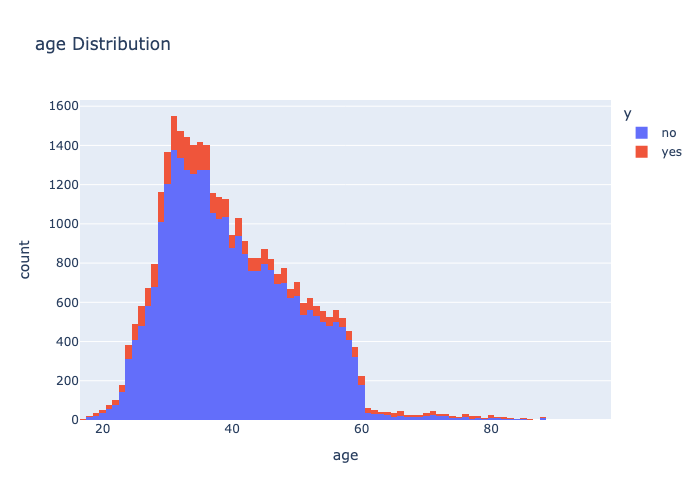

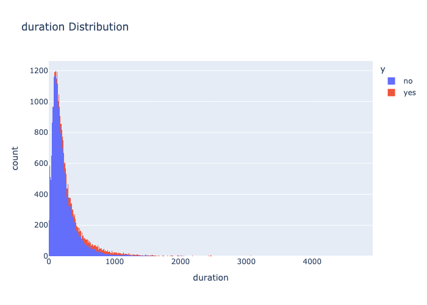

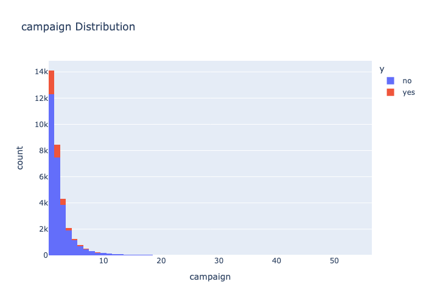

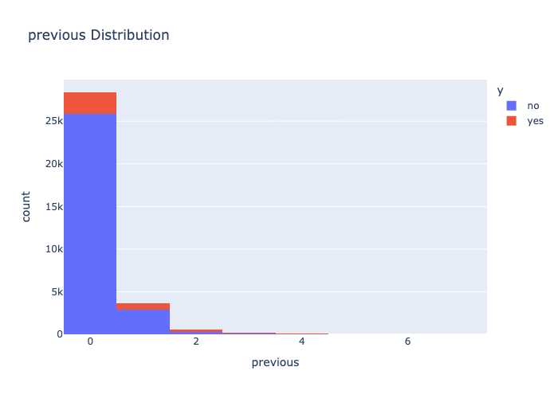

```python
plot_distributions(df, cols=l_num_cols, outcome='y')
```

## 4 4. Distributions - Categorical Variables

Majority of the target customers * are blue-collar worker,s admins, and technicians (this group also include the highest number of success). * are married * have a university degree (majority success) * doesn’t have a credit in default (majority success which seems sensible) * has a housing loan (although not a significant difference with the no-housing loan group). Given the success of the product marketing, having a house loan doesn’t seem to have a big impact. * doesn’t have a personal loan. Personal loans seem to have sone impact. And most (last) contacts were made in May. Previous outcome column indicates that most of the customers doesn’t have a previous outcome history which may indicate that they are the first time contact - or this information cannot be gathered. Again, there’s higher success in this group.

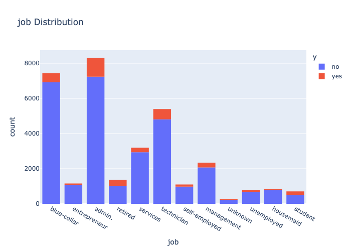

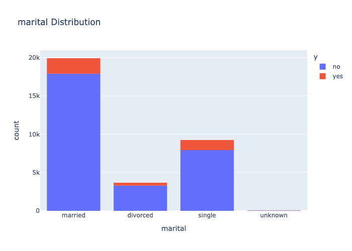

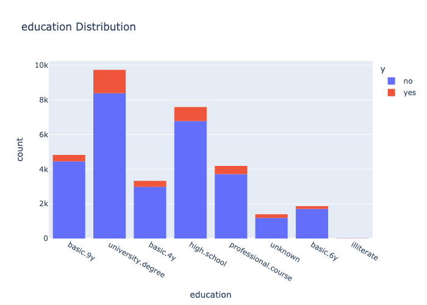

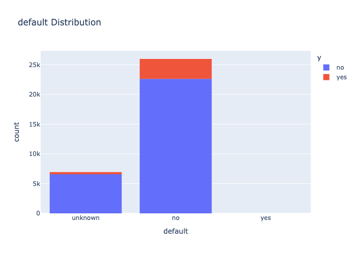

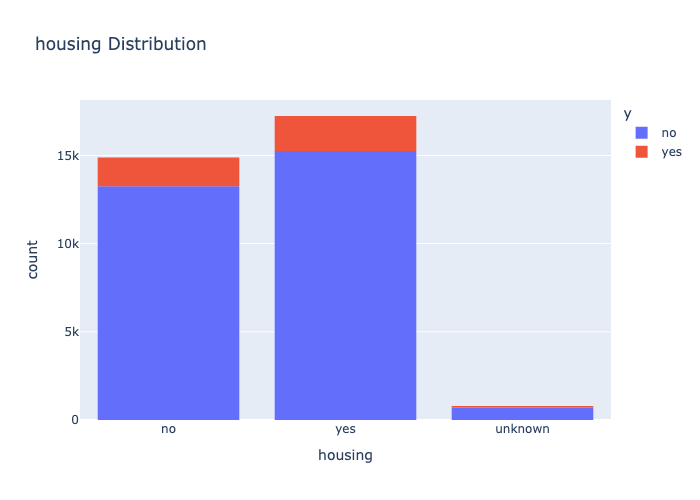

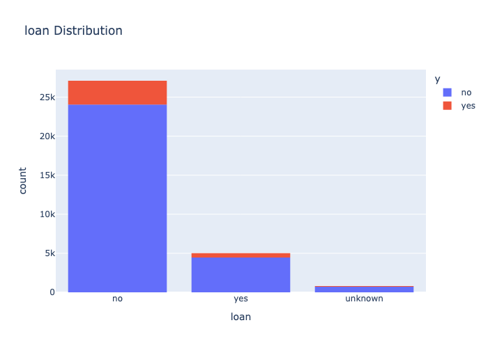

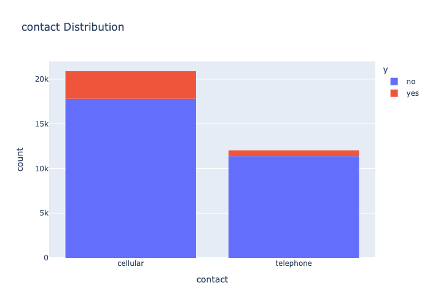

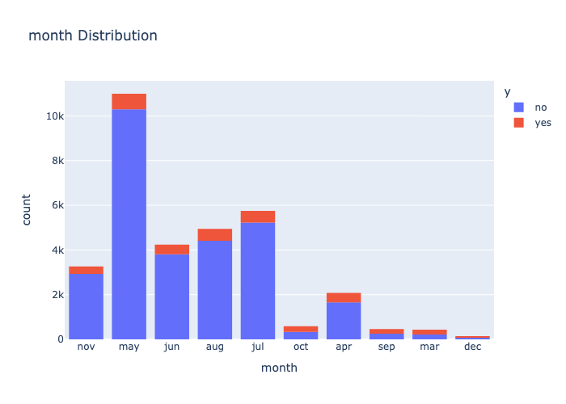

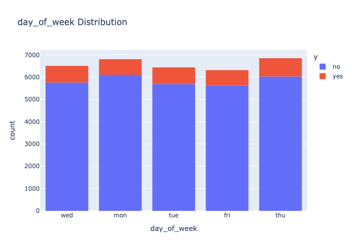

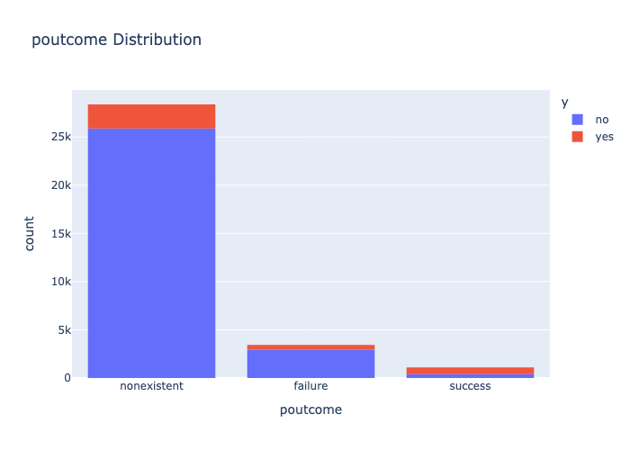

```python
plot_distributions(df, cols=l_cat_cols, outcome='y')
```